# Problem Set 2

Author

Owen Brooks

Published

October 16, 2026

**GitHub repo:** https://github.com/owengbrooks/ec422_ps2_owenbrooks/tree/main

```r
library(tidyverse)
library(knitr)
library(ggplot2)
source("ps2_script_owenbrooks.R")
```

```
✖ zoo::as.Date()                 masks base::as.Date()
✖ zoo::as.Date.numeric()         masks base::as.Date.numeric()
```

## Data

```r
head(unemp_raw)
```

```
# A tibble: 6 × 3
  symbol date       price
  <chr>  <date>     <dbl>
1 UNRATE 1976-01-01   7.9
2 UNRATE 1976-02-01   7.7
3 UNRATE 1976-03-01   7.6
4 UNRATE 1976-04-01   7.7
5 UNRATE 1976-05-01   7.4
6 UNRATE 1976-06-01   7.6
```

The data are seasonally adjusted unemployment rates for the U.S.. There are four states: Oregon (ORUR), California (CAUR), Texas (TXUR), and New York (NYUR). I pulled them technically from FRED in the tidyquant library and then saved it as a rds file. The data starts in Jan 1976 and ends in Sept 2026 which yields 3041 observations. There are three columns with the rate, date, and where it is coming from. There is an observation per month minus times when the Government shut down.

## Wrangling

```r
kable(unemp_summary, digits=2,
      caption = "Summary statistics for monthly unemployment rates by region, 1976–2026")
```

Summary statistics for monthly unemployment rates by region, 1976–2026

| region | mean_rate | min_rate | max_rate |
| --- | --- | --- | --- |
| California | 7.07 | 3.8 | 16.1 |
| New York | 6.35 | 3.8 | 16.7 |
| Oregon | 6.66 | 3.4 | 13.7 |
| Texas | 5.85 | 3.4 | 12.8 |
| US | 6.05 | 3.4 | 14.8 |

Summary statistics for monthly unemployment rates by region, January 2015 onward

[output not shown]

```r
kable(unemp_top_increases_no_covid, digits=2,
      caption = "Largest month-over-month increases in unemployment, excluding COVID-19")
```

Largest month-over-month increases in unemployment, excluding COVID-19

| symbol | date | unemployment_rate | region | unemployment_rate_change |
| --- | --- | --- | --- | --- |
| TXUR | 2009-05-01 | 7.6 | Texas | 1.1 |
| ORUR | 2008-12-01 | 8.9 | Oregon | 0.7 |
| ORUR | 2008-11-01 | 8.2 | Oregon | 0.7 |
| ORUR | 2009-01-01 | 9.6 | Oregon | 0.7 |
| ORUR | 1980-03-01 | 7.4 | Oregon | 0.6 |
| UNRATE | 1980-04-01 | 6.9 | US | 0.6 |

```r
kable(unemp_top_decreases_no_covid, digits=2,
      caption = "Largest month-over-month decreases in unemployment, excluding COVID-19")
```

Largest month-over-month decreases in unemployment, excluding COVID-19

| symbol | date | unemployment_rate | region | unemployment_rate_change |
| --- | --- | --- | --- | --- |
| UNRATE | 1983-07-01 | 9.4 | US | -0.7 |
| NYUR | 2021-09-01 | 6.2 | New York | -0.6 |
| ORUR | 1977-05-01 | 7.8 | Oregon | -0.5 |
| CAUR | 2021-07-01 | 7.4 | California | -0.5 |
| CAUR | 2021-09-01 | 6.5 | California | -0.5 |
| NYUR | 2021-07-01 | 7.0 | New York | -0.5 |
| UNRATE | 2010-12-01 | 9.3 | US | -0.5 |
| UNRATE | 2014-04-01 | 6.2 | US | -0.5 |
| UNRATE | 2021-07-01 | 5.4 | US | -0.5 |

## Visualization

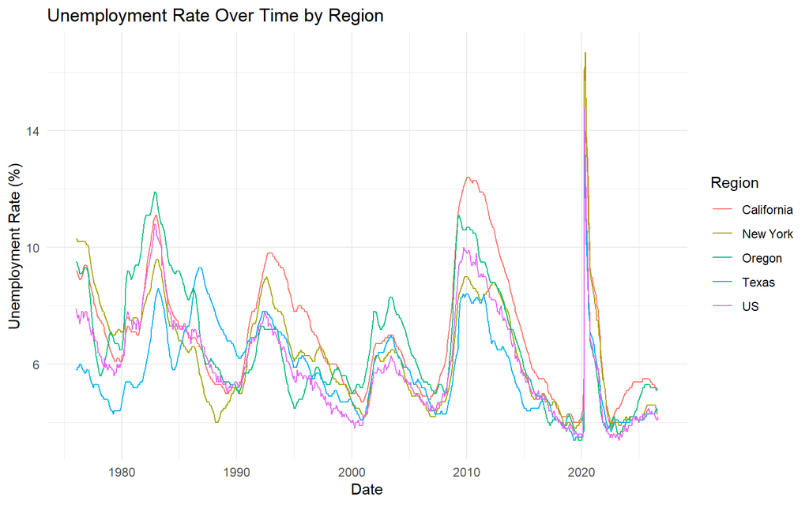

Monthly unemployment rate by region, 1976–2026

```r
unemp_line_plot
```

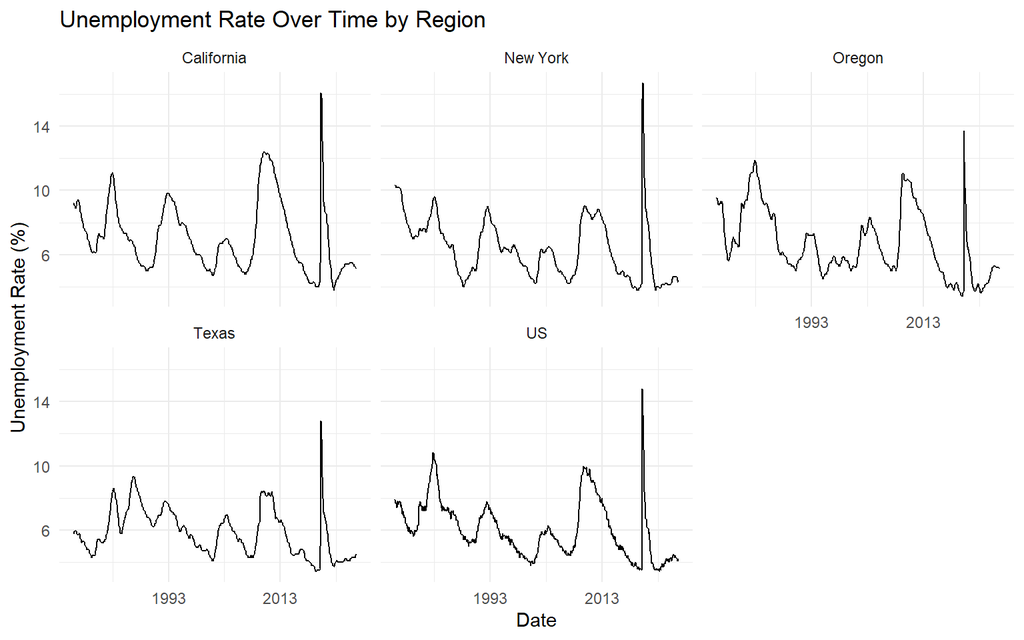

Monthly unemployment rate, shown separately for each region

```r
unemp_line_plot_indv
```

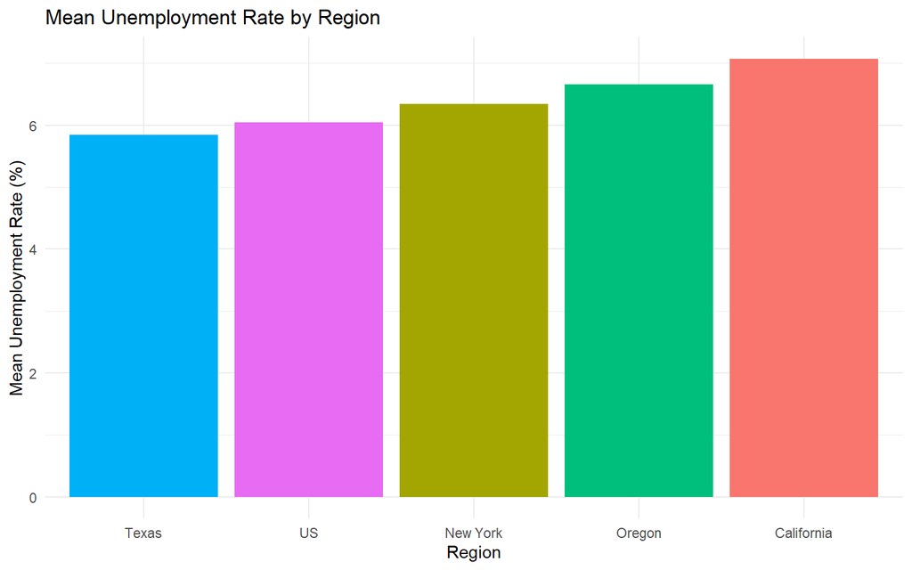

Mean monthly unemployment rate by region, 1976–2026

```r
unemp_bar_chart
```

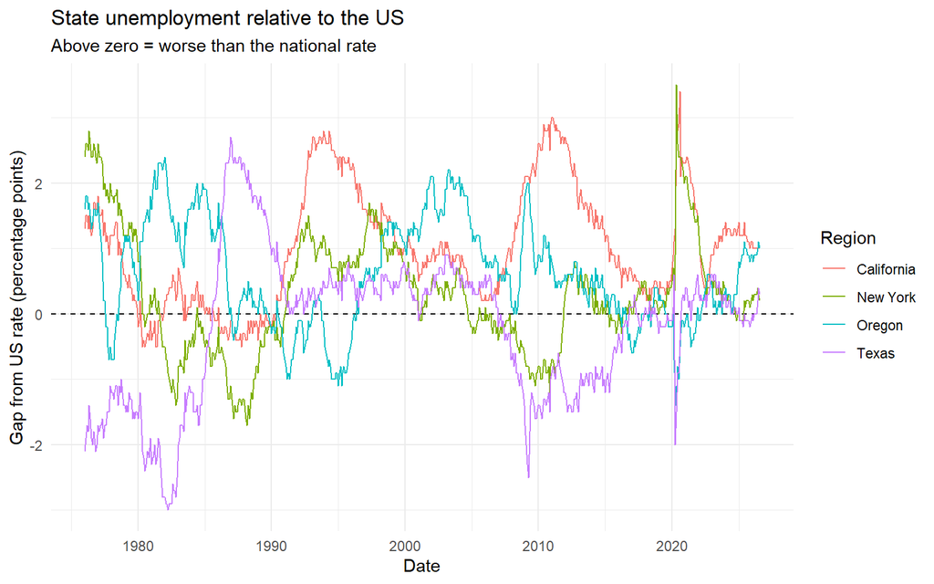

Difference between each state’s unemployment rate and the US rate, in percentage points. Positive values mean the state’s rate was higher than the national rate

```r
unemp_gap_plot
```

I chose to graph each state’s unemployment rate *relative* to the national average. Doing this we can isolate the *composition* of the national unemployment rate and tell stories about what was happening. For example, in the 1980s Texas unemployment rate was around 2pp lower than the national average. After some research, this was due to the high oil prices post-1979 Iranian Revolution which drove employment growth in Texas during a time when Volcker brought up rates significantly and unemployment was high. Then when oil prices shot down in 86’, unemployment in Texas shot up.

## Reflection

This process was relatively smooth for me. Github is a fantastic version control system that I have been using for a long time so I felt comfortable with it. One thing that was really nice was the Github Copilot auto-complete feature which spared me from hours of ggplot2 syntax but still let me be in the weeds enough to get a feel of the data. I experimented with using the source() function in quarto to retrieve objects from the R script as well as some rendering options which I think, aesthetically, worked out wonderfully. At first I got some rendering errors using the source() function but after clicking the source on save check-box in the R script everything sailed smoothly.